# Where is the Money for Feminist Organizing? Survey for feminist, women’s rights and gender justice movements, groups and organizations

2024-07-19

#WITM follow up

**Database upload**

```r
# To upload CSV file
witm <- read.csv2("Data/WITM_csv_0716.csv")

#2024-05-23 08:37:41.178000-04:00
witm$date <-  as.Date(witm$end,'%Y-%m-%d')


#names(witm)
# To upload xlsx file
#datos<- read_xlsx("WITM_xls_value2.xlsx", sheet = 1)
```

**-.-.-.-.-.-.-.-.-.-.-.-.-.-.-.-.-.-.-.-.-.-.-.-.-.-.-.-.-.-**

**Number of answers by date**

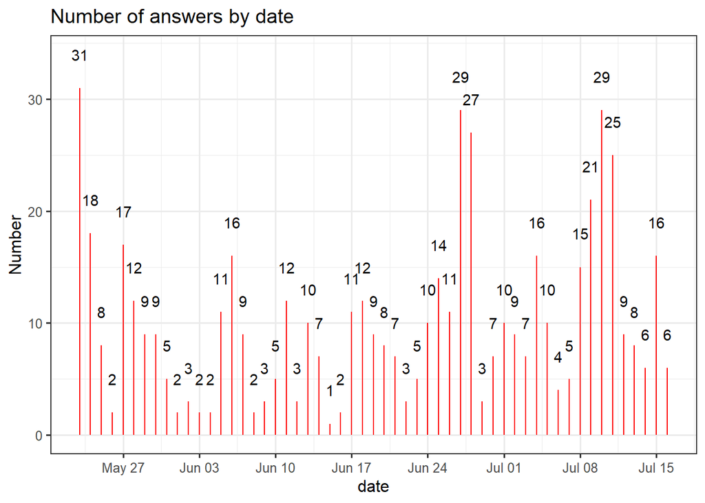

**–Analysis notes———————————————————————–**

In general the polls always have a high peak on the firsts days, WITM also shows this. Then there is another spike on 27-28 June, probably a strengthening of communication. On the 4th of July it increases again. During the days of the sessions, the number of responses also increased significantly.

**————————————————————————————————**

**-.-.-.-.-.-.-.-.-.-.-.-.-.-.-.-.-.-.-.-.-.-.-.-.-.-.-.-.-.-**

**Consent:**

Q1. I consent to take the WITM survey on behalf of my group, organization or movement.

| Consent | n | porcentaje |
| --- | --- | --- |
| no | 25 | 4.5 |
| yes | 528 | 95.5 |

**-.-.-.-.-.-.-.-.-.-.-.-.-.-.-.-.-.-.-.-.-.-.-.-.-.-.-.-.-.-**

**Group information:**

Q2. Which of the following statements best describes your group, organization and/or movement?

| Description | n | porcentaje |
| --- | --- | --- |
| We promote the rights of women or girls or trans or gender diverse people with intersecting identities ‘through specific project(s)’, but not as the primary focus of our work | 86 | 16.3 |
| We promote the rights of women or girls or trans or gender diverse people in all their intersecting identities and this is the ‘primary focus of all our work’ | 402 | 76.1 |
| Other | 40 | 7.6 |

**–Analysis notes———————————————————————–**

The majority of the organizations indicate that they are feminist organizations. This means that it is not a variable that allows us to characterize or discriminate the organizations very much.

**————————————————————————————————**

**-.-.-.-.-.-.-.-.-.-.-.-.-.-.-.-.-.-.-.-.-.-.-.-.-.-.-.-.-.-**

**Organization names:**

Q3. The name of your group, organization and/or movement

```
## [1] "The number of organisations that did not answer their name is: 33"
```

**–Analysis notes———————————————————————–**

Very interesting that almost all organisations responded with their name despite the fact that the possibility of not responding is informed and underlined.

**————————————————————————————————**

**-.-.-.-.-.-.-.-.-.-.-.-.-.-.-.-.-.-.-.-.-.-.-.-.-.-.-.-.-.-**

**Type of organization**

Q4. Which of the following forms of organizing best describes your group, organization and/or movement?

*This is a multiple-choice question so the sum of the % does NOT add up to 100.*

| Organization type | n | porcentaje |
| --- | --- | --- |
| Women’s rights | 408 | 77.3 |
| Ending gender based violence | 360 | 68.2 |
| Human rights | 307 | 58.1 |
| Sexual and reproductive health & rights (SRHR) and bodily autonomy | 300 | 56.8 |
| Young feminists | 199 | 37.7 |
| Economic justice, rights and alternatives | 176 | 33.3 |
| Human rights defenders at risk | 175 | 33.1 |
| Climate and environmental justice | 164 | 31.1 |
| Girls’ movements | 149 | 28.2 |
| Disability rights and justice | 139 | 26.3 |
| Lesbian, Bisexual and queer rights | 135 | 25.6 |
| Sex workers rights | 134 | 25.4 |
| Rights for people living with HIV+ | 127 | 24.1 |
| Countering anti-gender and anti-rights | 114 | 21.6 |
| Indigenous rights | 108 | 20.5 |
| Displaced, migrant and refugee rights | 106 | 20.1 |
| Holistic safety, protection and collective care | 105 | 19.9 |
| Trans and non-binary rights | 102 | 19.3 |
| Labour rights | 101 | 19.1 |
| Crisis response | 94 | 17.8 |
| Digital rights | 90 | 17.0 |
| Freedom of information and media | 73 | 13.8 |
| Racial justice | 71 | 13.4 |
| Black rights/ Black feminist rights | 70 | 13.3 |
| Harm reduction | 69 | 13.1 |
| Pleasure and bodily care | 62 | 11.7 |
| Intersex rights | 58 | 11.0 |
| Anti-militarization and peace | 49 | 9.3 |
| Religious and ethnic minority rights | 46 | 8.7 |
| Other | 31 | 5.9 |
| Resisting the war on drugs | 26 | 4.9 |
| Anti-caste | 15 | 2.8 |

**–Analysis notes———————————————————————–**

Most of the organisations selected many options. Almost all of them defined one of the first four options. Only 10% did not select any of them and in general selected others that can be integrated.

A recategorization into groups of options is proposed in the following item. Excluding the first 4 options: Women’s rights Ending gender based violence Human rights Sexual and reproductive health & rights (SRHR) and bodily autonoms

**-.-.-.-.-.-.-.-.-.-.-.-.-.-.-.-.-.-.-.-.-.-.-.-.-.-.-.-.-.-**

**Type of organization - grouping**

In order to make it easier to analyse, groups can be made, but they are not mutually exclusive, so **they are still multiple options**.

THIS CAN BE DEFINED DIFFERENTLY. POSSIBLE GROUPINGS SHOULD BE INDICATED

Sexual and reproductive health & rights (SRHR) and bodily autonomy

**Feminist specifit subjects** Girls’ movements. Young feminists . Countering anti-gender and anti-rights Lesbian, Bisexual and queer rights Sex workers rights Trans and non-binary rights Intersex rights

**General HR subjects** Human rights defenders at risk Economic justice, rights and alternatives Climate and environmental justice Anti-militarization and peace Crisis response Resisting the war on drugs Anti-caste Digital rights Freedom of information and media

**Intersectionality (minority groups)** Disability rights and justice Displaced, migrant and refugee rights Indigenous rights Racial justice Black rights/ Black feminist rights Religious and ethnic minority rights

**Sexual and reproductive health & rights (and others health rights)** Rights for people living with HIV+ Holistic safety, protection and collective care Pleasure and bodily care

| Organization grouped type | n | porcentaje |
| --- | --- | --- |
| General HR subjects | 366 | 69.3 |
| Feminist specifit subjects | 360 | 68.2 |
| Intersectionality (minority groups) | 264 | 50.0 |
| Sexual and reproductive health & rights (and othershealth rights) | 213 | 40.3 |

**–Analysis notes———————————————————————–**

The problem with this question is that it does not allow us to discriminate much in relation to organizations.

How can we group these organizations in order to better analyze the data?

**-.-.-.-.-.-.-.-.-.-.-.-.-.-.-.-.-.-.-.-.-.-.-.-.-.-.-.-.-.-**

**Organisation type & subjetcs - grouped**

Option 1

| Description | Specific projects | Primary focus | Other |
| --- | --- | --- | --- |
| Specific feminist subjects | 62.79 | 70.15 | 60.00 |
| General HR Subjects | 69.77 | 68.66 | 75.00 |
| Intersectionality (minority groups) | 48.84 | 49.25 | 60.00 |
| Sexual and reproductive health & rights | 37.21 | 40.80 | 42.50 |

```
## # A tibble: 3 × 5
##   Description       `Specific feminist subjects` `General HR Subjects`
##   <chr>                                    <dbl>                 <dbl>
## 1 Specific projects                         62.8                  69.8
## 2 Primary focus                             70.2                  68.7
## 3 Other                                     60                    75
## # ℹ 2 more variables: `Intersectionality (minority groups)` <dbl>,
## #   `Sexual and reproductive health & rights` <dbl>
```

```
## # A tibble: 8 × 3
##   Description       q4_grouped                              percentage
##   <chr>             <chr>                                        <dbl>
## 1 Specific projects Specific feminist subjects                    62.8
## 2 Specific projects General HR Subjects                           69.8
## 3 Specific projects Intersectionality (minority groups)           48.8
## 4 Specific projects Sexual and reproductive health & rights       37.2
## 5 Primary focus     Specific feminist subjects                    70.2
## 6 Primary focus     General HR Subjects                           68.7
## 7 Primary focus     Intersectionality (minority groups)           49.2
## 8 Primary focus     Sexual and reproductive health & rights       40.8
```

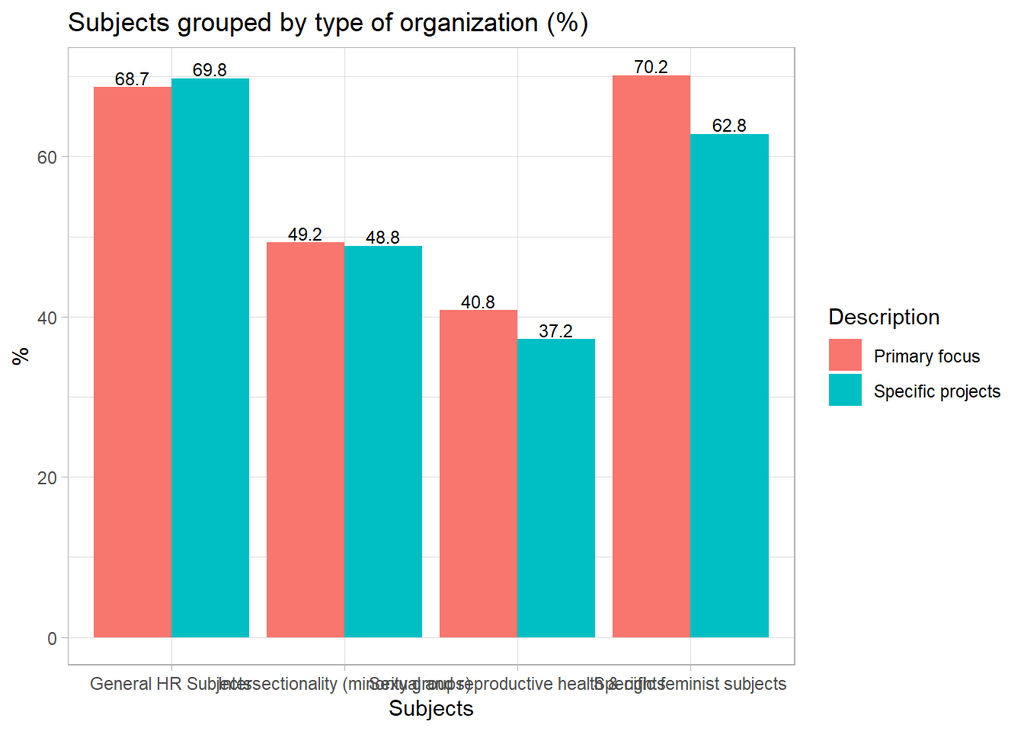

**————————————————————————————————**

**Organisation type & subjetcs - grouped**

Option 2

| q1_description | Specific feminist subjects (A) | HR general subjects (B) | Intersectionality subjects (C) | Sexual and reproductive health & rights (D) |
| --- | --- | --- | --- | --- |
| Primary focus | 78.3 | 75.4 | 75.0 | 77 |
| Specific projects | 15.0 | 16.4 | 15.9 | 15 |
| Other | 6.7 | 8.2 | 9.1 | 8 |

**–Analysis notes———————————————————————–**

This crosstabulation shows the information upside down. It indicates that: among the organizations that indicated that they work on some of the main issues of the feminist agenda, 78.3% indicated that they work with a focus on that agenda and 15% through projects. The distribution is very stable among all the issues.

**————————————————————————————————**

**-.-.-.-.-.-.-.-.-.-.-.-.-.-.-.-.-.-.-.-.-.-.-.-.-.-.-.-.-.-**

**Register**

Q5. Is your group, organization and/or movement registered?

| Register | n | porcentaje |
| --- | --- | --- |
| Yes | 431 | 81.6 |
| No | 79 | 15.0 |
| Other | 15 | 2.8 |
| NA | 3 | 0.6 |

**-.-.-.-.-.-.-.-.-.-.-.-.-.-.-.-.-.-.-.-.-.-.-.-.-.-.-.-.-.-**

**Register by type of organisation**

A crosstabulation (bivariate) of the combination of organization type and registration is shown.

| Registered | Primary focus | Specific Projects | Other |
| --- | --- | --- | --- |
| Registered | 81 | 88.4 | 80 |
| No registered | 16 | 10.5 | 15 |
| Other | 3 | 1.2 | 5 |

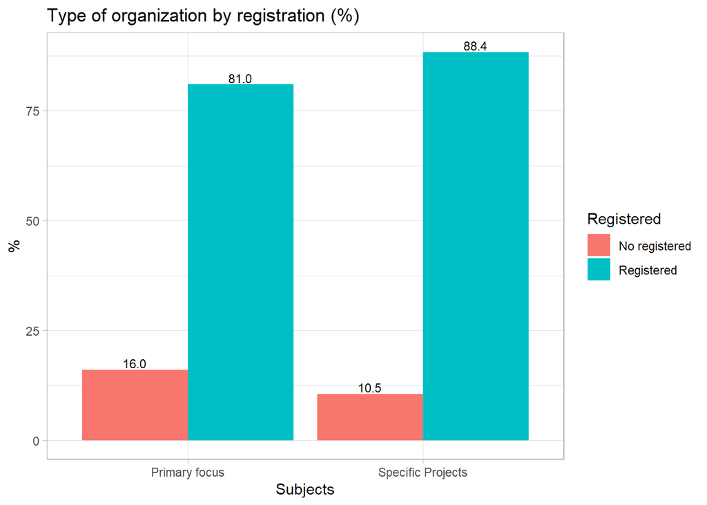

**–Analysis notes———————————————————————–**

The behavior between “primary focus” and “specific projects” organizations is similar in terms of registration. There are slightly more unregistered primary focus organizations, but this is not a relevant difference.

**————————————————————————————————**

**-.-.-.-.-.-.-.-.-.-.-.-.-.-.-.-.-.-.-.-.-.-.-.-.-.-.-.-.-.-**

**Register by subject - grouped** A crosstabulation (bivariate) of the combination of registration and subject of the organisation

| q5_registered | Specific feminist subjects (A) | HR general subjects (B) | Intersectionality subjects (C) | Sexual and reproductive health & rights (D) |
| --- | --- | --- | --- | --- |
| Registered | 80.1 | 83.5 | 84.4 | 80.3 |
| No registered | 16.8 | 14.6 | 13.4 | 16.9 |
| Other | 3.1 | 1.9 | 2.3 | 2.8 |

**–Analysis notes———————————————————————–**

This cross-tabulation allows for comparison according to the issues they address and whether or not the organizations are registered. Reading: among those working mainly on specific feminist issues, 80% are registered, while among those working on general human rights issues, this value rises to 83%.

**————————————————————————————————**

**-.-.-.-.-.-.-.-.-.-.-.-.-.-.-.-.-.-.-.-.-.-.-.-.-.-.-.-.-.-**

**Scope:**

Q6. What is the geographical scope of your work?

| Geo scope | n | porcentaje |
| --- | --- | --- |
| Work from diaspora, refuge and/or exile | 5 | 0.9 |
| Global | 35 | 6.6 |
| Locally | 163 | 30.9 |
| Nationally | 264 | 50.0 |
| Regionally | 52 | 9.8 |
| Transnationally | 9 | 1.7 |

**–Analysis notes———————————————————————–** The sample is very interesting because most of the organizations are national or local (80%).

**————————————————————————————————** ___

**-.-.-.-.-.-.-.-.-.-.-.-.-.-.-.-.-.-.-.-.-.-.-.-.-.-.-.-.-.-**

**Scope by type of organisation**

A crosstabulation (bivariate) of the combination of type of organization type and scope

| q1_description | Nationally | Locally | Regionally | Global | Work from diaspora, refuge and/or exile | Transnationally |
| --- | --- | --- | --- | --- | --- | --- |
| primary_focus | 75.4 | 77.9 | 75.0 | 82.9 | 100 | 33.3 |
| specific_projects | 15.5 | 16.0 | 19.2 | 14.3 | NA | 44.4 |
| 98 | 9.1 | 6.1 | 5.8 | 2.9 | NA | 22.2 |

```
## # A tibble: 16 × 3
## # Groups:   Scope [6]
##    q1_description    Scope                                   percentage
##    <chr>             <chr>                                        <dbl>
##  1 primary_focus     Nationally                                    75.4
##  2 primary_focus     Locally                                       77.9
##  3 specific_projects Nationally                                    15.5
##  4 primary_focus     Regionally                                    75
##  5 primary_focus     Global                                        82.9
##  6 specific_projects Locally                                       16
##  7 98                Nationally                                     9.1
##  8 98                Locally                                        6.1
##  9 specific_projects Regionally                                    19.2
## 10 primary_focus     Work from diaspora, refuge and/or exile      100
## 11 specific_projects Global                                        14.3
## 12 specific_projects Transnationally                               44.4
## 13 98                Regionally                                     5.8
## 14 primary_focus     Transnationally                               33.3
## 15 98                Transnationally                               22.2
## 16 98                Global                                         2.9
```

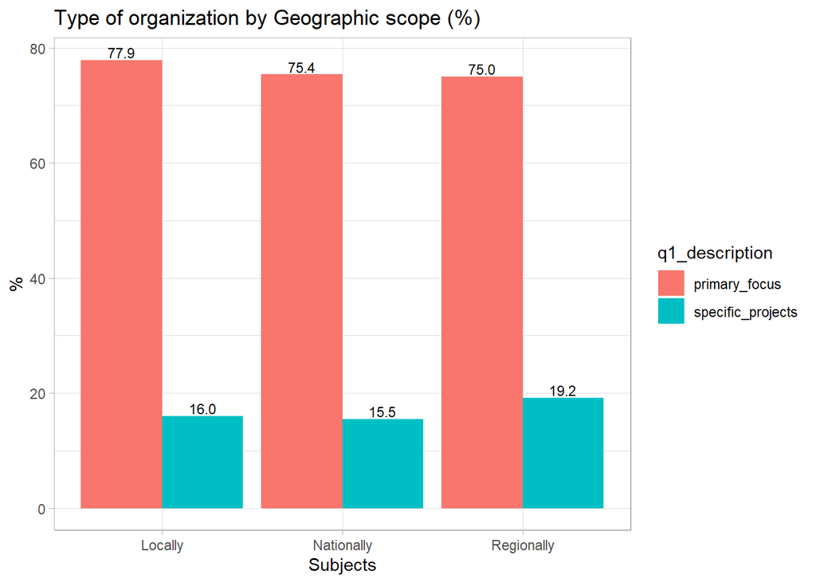

**–Analysis notes———————————————————————–**

So far, due to the size of the sample, it is only convenient to analyze this crossover for the 3 most numerous groups: national, local and regional. In these 3 cases, the distribution is homogeneous, and there is a slight tendency to work on feminism and gender issues through projects for regional organizations.

**————————————————————————————————**

**-.-.-.-.-.-.-.-.-.-.-.-.-.-.-.-.-.-.-.-.-.-.-.-.-.-.-.-.-.-**

**Scope by registration**

A crosstabulation (bivariate) of the combination of registered and scope

| q5_registered | Nationally | Locally | Regionally | Global | Transnationally | Work from diaspora, refuge and/or exile |
| --- | --- | --- | --- | --- | --- | --- |
| Registered | 84.1 | 78.5 | 76.9 | 80 | 88.9 | 100 |
| No registered | 13.6 | 16.6 | 15.4 | 20 | 11.1 | NA |
| Other | 1.9 | 3.7 | 7.7 | NA | NA | NA |
|  | 0.4 | 1.2 | NA | NA | NA | NA |

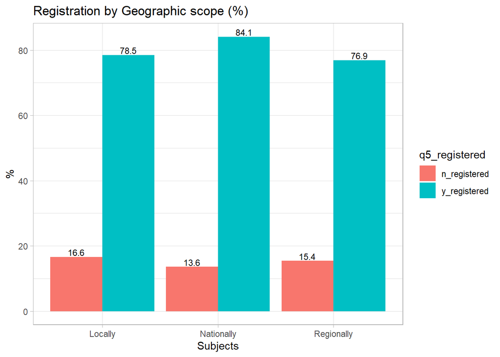

**–Analysis notes———————————————————————–** The same analysis as before shows that there is a greater tendency for local organizations to be unregistered.

**————————————————————————————————**

**-.-.-.-.-.-.-.-.-.-.-.-.-.-.-.-.-.-.-.-.-.-.-.-.-.-.-.-.-.-**

**Scope & subjetcs - grouped**

Option 1

```
## # A tibble: 3 × 5
##   Scope      Specific feminist su…¹ `General HR Subjects` Intersectionality (m…²
##   <chr>                       <dbl>                 <dbl>                  <dbl>
## 1 Locally                      68.1                  66.9                   47.2
## 2 Nationally                   67.8                  69.3                   51.5
## 3 Regionally                   73.1                  65.4                   36.5
## # ℹ abbreviated names: ¹`Specific feminist subjects`,
## #   ²`Intersectionality (minority groups)`
## # ℹ 1 more variable: `Sexual and reproductive health & rights` <dbl>
```

| Scope | Locally | Nationally | Regionally |
| --- | --- | --- | --- |
| Specific feminist subjects | 68.10 | 67.80 | 73.08 |
| General HR Subjects | 66.87 | 69.32 | 65.38 |
| Intersectionality (minority groups) | 47.24 | 51.52 | 36.54 |
| Sexual and reproductive health & rights | 47.24 | 37.50 | 44.23 |

**–Analysis notes———————————————————————–**

Regional organizations work more often on specifically feminist issues than on group issues, at least in relation to local and national organizations.

**————————————————————————————————**

**-.-.-.-.-.-.-.-.-.-.-.-.-.-.-.-.-.-.-.-.-.-.-.-.-.-.-.-.-.-**

**Scope & subjetcs - grouped**

Option 2: how is distributed inside each subject the scope Absolutes numbers

| q6_geo_scope | Specific feminist subjects (A) | HR general subjects (B) | Intersectionality subjects (C) | Sexual and reproductive health & rights (D) |
| --- | --- | --- | --- | --- |
| Nationally | 179 | 183 | 136 | 99 |
| Locally | 111 | 109 | 77 | 77 |
| Regionally | 38 | 34 | 19 | 23 |
| Global | 24 | 29 | 20 | 11 |
| Transnationally | 6 | 7 | 8 | 2 |
| Work from diaspora, refuge and/or exile | 2 | 4 | 4 | 1 |

**–Analysis notes———————————————————————–**

These data allow us to see how many organizations of each type indicated working on each of the topics. This crosswalk is useful during implementation, then it should be replaced by the percentage.

**————————————————————————————————**

**-.-.-.-.-.-.-.-.-.-.-.-.-.-.-.-.-.-.-.-.-.-.-.-.-.-.-.-.-.-**

**Region:**

Q7. Indicate in which region(s) your group, organization and/or movement works

| Region | n | porcentaje |
| --- | --- | --- |
| South Asia | 94 | 61.4 |
| East Africa | 87 | 56.9 |
| South America | 86 | 56.2 |
| West Africa | 73 | 47.7 |
| Central America & Mexico | 61 | 39.9 |
| Southeast Asia | 53 | 34.6 |
| Central Africa | 48 | 31.4 |
| Eastern Europe, Southeast Europe and Central Europe | 44 | 28.8 |
| Southern Africa | 38 | 24.8 |
| Western Europe | 35 | 22.9 |
| South West Asia/Middle East | 30 | 19.6 |
| The Pacific | 28 | 18.3 |
| North Africa | 27 | 17.6 |
| Caribbean | 23 | 15.0 |
| North America | 23 | 15.0 |
| East Asia | 16 | 10.5 |
| Central Asia & Caucasus | 10 | 6.5 |

**-.-.-.-.-.-.-.-.-.-.-.-.-.-.-.-.-.-.-.-.-.-.-.-.-.-.-.-.-.-**

**Region by register**

This is made now only for Locally and National organisations

| q5_registered | Registered | No registered | Other |  |
| --- | --- | --- | --- | --- |
| South Asia | 89.2 | 9.5 | 1.4 | NA |
| East Africa | 88.5 | 8.2 | 1.6 | 1.6 |
| West Africa | 89.4 | 6.4 | 4.3 | NA |
| South America | 71.4 | 24.5 | 2.0 | 2.0 |
| Central Africa | 97 | 3 | NA | NA |
| Southeast Asia | 69.7 | 21.2 | 9.1 | NA |
| Southern Africa | 90 | 10 | NA | NA |
| Central America & Mexico | 65.4 | 30.8 | 3.8 | NA |
| Eastern Europe, Southeast Europe and Central Europe | 76.5 | 23.5 | NA | NA |
| The Pacific | 80.0 | 13.3 | NA | 6.7 |
| Western Europe | 90.9 | 9.1 | NA | NA |
| South West Asia/Middle East | 77.8 | 22.2 | NA | NA |
| Caribbean | 85.7 | 14.3 | NA | NA |
| East Asia | 100 | NA | NA | NA |
| North Africa | 37.5 | 62.5 | NA | NA |
| Central Asia & Caucasus | 100 | NA | NA | NA |
| North America | 28.6 | 42.9 | 28.6 | NA |

**–Analysis notes———————————————————————–**

Between local and national organizations there is a big difference in how many are unregistered in the different regions. The region with the highest proportion of unregistered is North Africa followed by North America.

**————————————————————————————————**

**-.-.-.-.-.-.-.-.-.-.-.-.-.-.-.-.-.-.-.-.-.-.-.-.-.-.-.-.-.-**

**Country:**

Q8. Which countries are you working in?

| q7_region_one | q8_country | n | Percentage |
| --- | --- | --- | --- |
| East Africa | Kenya | 22 | 36.1 |
| East Africa | South Sudan | 3 | 4.9 |
| East Africa | Uganda | 17 | 27.9 |
| East Africa | Rwanda | 4 | 6.6 |
| East Africa | Burundi | 4 | 6.6 |
| East Africa | Tanzania | 7 | 11.5 |
| East Africa | Malawi | 1 | 1.6 |
| East Africa | Mozambique | 1 | 1.6 |
| East Africa | Ethiopia | 2 | 3.3 |
| North America | United States of America | 3 | 42.9 |
| North America | Canada | 3 | 42.9 |
| North America | NA | 1 | 14.3 |
| Central Africa | Democratic Republic of the Congo | 22 | 66.7 |
| Central Africa | Cameroon | 5 | 15.2 |
| Central Africa | Central African Republic | 2 | 6.1 |
| Central Africa | Other Central Africa | 1 | 3.0 |
| Central Africa | Chad | 1 | 3.0 |
| Central Africa | Angola | 1 | 3.0 |
| Central Africa | NA | 1 | 3.0 |
| Southeast Asia | Thailand | 2 | 6.1 |
| Southeast Asia | Malaysia | 2 | 6.1 |
| Southeast Asia | Indonesia | 6 | 18.2 |
| Southeast Asia | Cambodia | 1 | 3.0 |
| Southeast Asia | Myanmar | 9 | 27.3 |
| Southeast Asia | Philippines | 4 | 12.1 |
| Southeast Asia | Other Southeast Asia | 5 | 15.2 |
| Southeast Asia | Viet Nam | 1 | 3.0 |
| Southeast Asia | NA | 3 | 9.1 |
| South Asia | Bangladesh | 12 | 16.2 |
| South Asia | Sri Lanka | 5 | 6.8 |

[output cut: 80 more lines]

**–Analysis notes———————————————————————–**

This is the detailed list that allows you to see in which countries the answers were obtained, not those that did not have a response

**————————————————————————————————**

**-.-.-.-.-.-.-.-.-.-.-.-.-.-.-.-.-.-.-.-.-.-.-.-.-.-.-.-.-.-**

**Year of formation:**

Q9. What year was your group, organization and/ or movement formed?

*Reading: 36% of the respondent organizations were formed between the years 2015 and 2020, while around 13% were formed from the year 2021 onwards*

Year formation

total

porcentaje

1. 2021-2023

59

13.8

2. From 2015 to 2020

153

35.8

3. From 2010 to 2014

68

15.9

4. From 2000 to 2009

97

22.7

5. Before 2000

50

11.7

**-.-.-.-.-.-.-.-.-.-.-.-.-.-.-.-.-.-.-.-.-.-.-.-.-.-.-.-.-.-**

**Year of formation & Register**

q5_registered

1. 2021-2023
2. From 2015 to 2020
3. From 2010 to 2014
4. From 2000 to 2009
5. Before 2000

Other

8.5

2.6

1.5

1.0

NA

No registered

35.6

17.6

11.8

5.2

4

Registered

55.9

79.1

83.8

93.8

96

NA

0.7

2.9

NA

NA

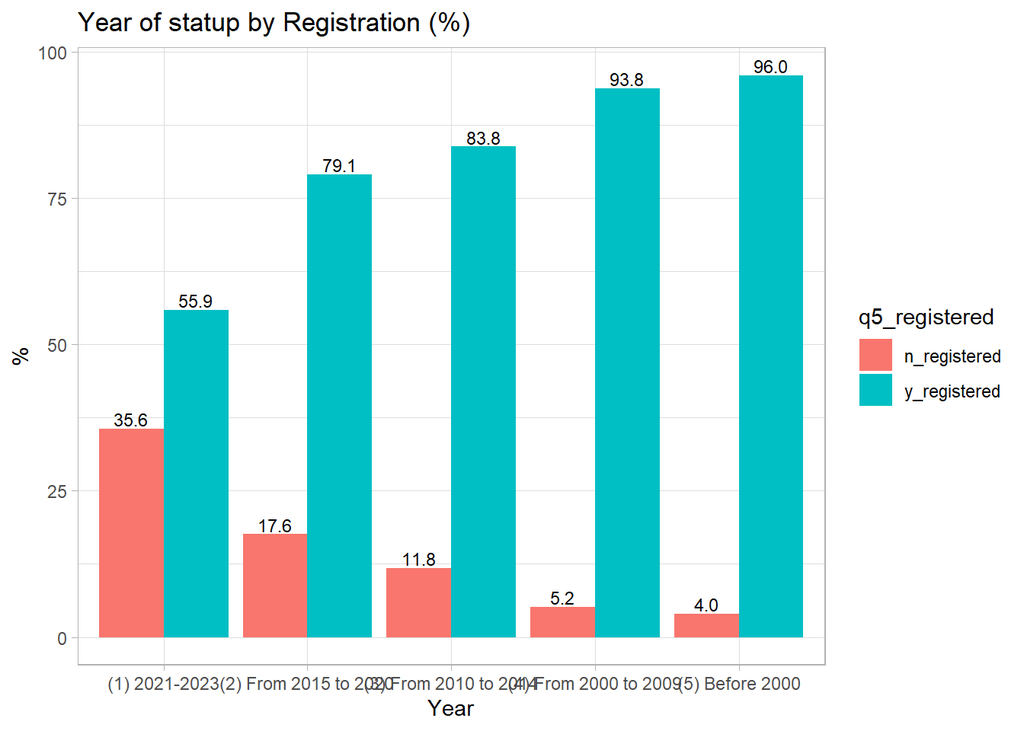

**–Analysis notes———————————————————————–**

Organizations starting in the last 3 years have a high proportion of non-registration. It decreases as the start-up time passes.

**————————————————————————————————**

**-.-.-.-.-.-.-.-.-.-.-.-.-.-.-.-.-.-.-.-.-.-.-.-.-.-.-.-.-.-**

**Year by type of organisation**

q1_description

1. 2021-2023
2. From 2015 to 2020
3. From 2010 to 2014
4. From 2000 to 2009
5. Before 2000

Other

8.5

7.2

10.3

7.2

8

Primary focus

78.0

77.1

76.5

75.3

74

Specific Projects

13.6

15.7

13.2

17.5

18

**–Analysis notes———————————————————————–**

**————————————————————————————————**

**-.-.-.-.-.-.-.-.-.-.-.-.-.-.-.-.-.-.-.-.-.-.-.-.-.-.-.-.-.-**

**Year by Gegraphically Scope**

Option 1

```
## # A tibble: 2 × 2
##   q6_geo_scope           n
##   <chr>              <int>
## 1 locally_focused      163
## 2 nationally_focused   264
```

q6_geo_scope

1. 2021-2023
2. From 2015 to 2020
3. From 2010 to 2014
4. From 2000 to 2009
5. Before 2000

Locally

42.4

39.9

42.6

34

30

Nationally

57.6

60.1

57.4

66

70

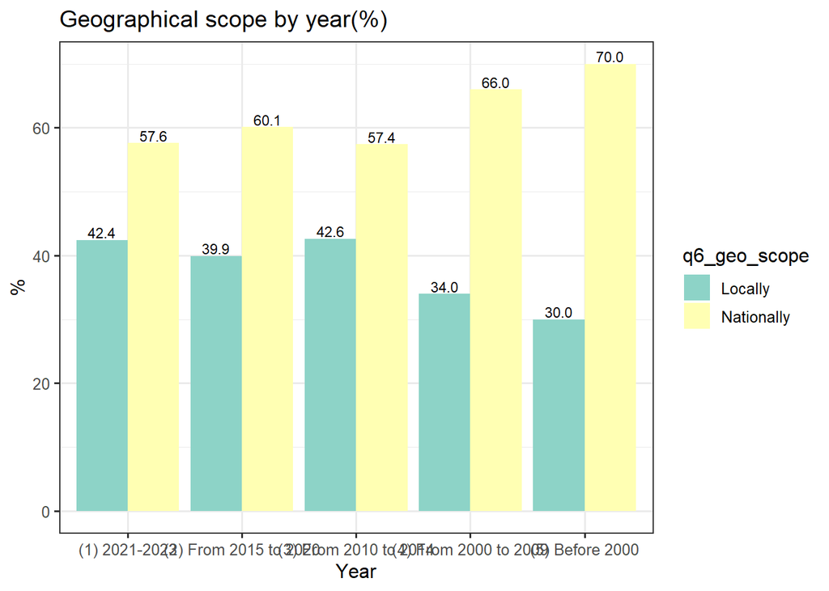

**–Analysis notes———————————————————————–**

The distribution is quite similar in all periods.

**————————————————————————————————**

**-.-.-.-.-.-.-.-.-.-.-.-.-.-.-.-.-.-.-.-.-.-.-.-.-.-.-.-.-.-** SECTION : EXTERNAL FOUNDING **-.-.-.-.-.-.-.-.-.-.-.-.-.-.-.-.-.-.-.-.-.-.-.-.-.-.-.-.-.-**

**External founding:**

Q13. Between 2021 and 2023, has your group, organization and/or movement received any external funding?

| External funding | n | porcentaje |
| --- | --- | --- |
| no | 120 | 28.1 |
| yes | 307 | 71.9 |